# Session 2 — Discrimination and Calibration

ROC and AUC · thresholds · sensitivity, specificity, PPV, NPV · calibration plot, slope and intercept · Brier score · Lab 2

Community Medicine Workshop

## Where we are

- Session 1: a model that gives a **risk** for each adult
- Today: **how good** are these risks? Two questions:
  - **Discrimination**: does the model **rank** adults with diabetes above those without?
  - **Calibration**: are the **risks themselves right**?
- (Both are still **apparent** here: in the development data)

# Topic 1 — Discrimination

## ROC curve and AUC

```r
roc1 <- roc(dev$diabetes, dev$risk, quiet = TRUE)
plot(roc1, legacy.axes = TRUE, col = col_blue, lwd = 3, print.auc = TRUE)
```

```r
ci.auc(roc1)
```

```
95% CI: 0.745-0.847 (DeLong)
```

**AUC 0.80** (95% CI 0.75 to 0.85). It is the probability that a **randomly chosen adult with diabetes has a higher predicted risk** than one without. **0.5 = coin toss, 1 = perfect**. A common reading: 0.7 to 0.8 acceptable, 0.8 to 0.9 good, but the **usefulness depends on the use**.

## ROC curve and AUC

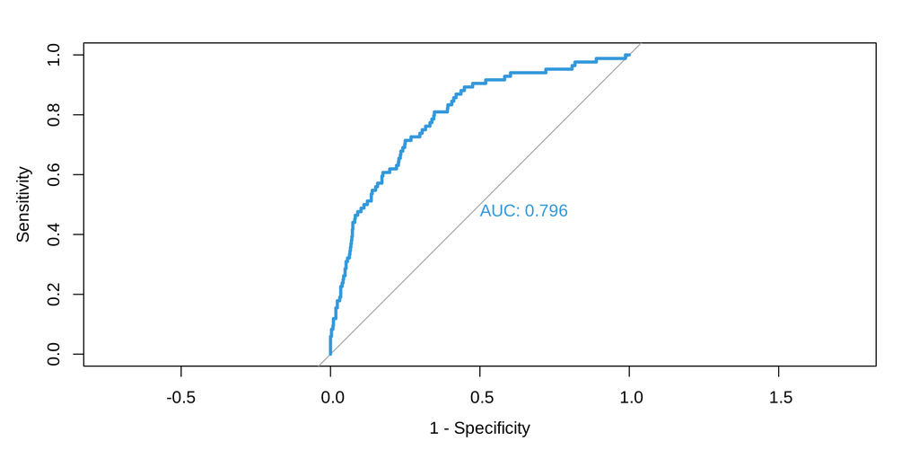

## A threshold

```r
tab <- table(predicted = dev$risk >= 0.15, diabetes = dev$diabetes); tab
```

```
         diabetes
predicted   0   1
    FALSE 483  32
    TRUE  133  52
```

```r
round(c(sensitivity = tab["TRUE", "1"] / sum(tab[, "1"]), specificity = tab["FALSE", "0"] / sum(tab[, "0"]),
        PPV = tab["TRUE", "1"] / sum(tab["TRUE", ]), NPV = tab["FALSE", "0"] / sum(tab["FALSE", ])), 2)
```

```
sensitivity specificity         PPV         NPV
       0.62        0.78        0.28        0.94
```

- At **15%**: sensitivity **0.62**, specificity **0.78**, PPV **0.28**, NPV **0.94**
- **Lower the threshold**: sensitivity **up**, specificity **down** (more adults tested)
- **PPV and NPV depend on the prevalence**: they change from district to district
- The **AUC** summarises **all thresholds**; the **choice of threshold** needs **costs and benefits** (Session 5)

## Added value

```r
c(age_only = auc_of(dev$diabetes, predict(glm(diabetes ~ age, data = dev, family = binomial), type = "response")), full_model = auc_of(dev$diabetes, dev$risk)) |> round(3)
```

```
  age_only full_model
     0.682      0.796
```

Age alone gives **0.68**; the full model **0.80**: the other predictors add **real discrimination**.

# Topic 2 — Calibration

## Calibration plot

```r
cal <- dev |> mutate(decile = ntile(risk, 10)) |> group_by(decile) |> summarise(predicted = mean(risk), observed = mean(diabetes))
ggplot(cal, aes(predicted, observed)) + geom_abline(linetype = 2) + geom_point(size = 3, colour = col_blue) + geom_line(colour = col_blue) + coord_equal(xlim = c(0, 0.6), ylim = c(0, 0.6)) + labs(x = "Mean predicted risk", y = "Observed proportion with diabetes")
```

Group the adults by **deciles of predicted risk** and compare the **mean predicted** with the **observed** proportion. **Points on the diagonal** = well calibrated. **Below** = the model **over-estimates**; **above** = it **under-estimates**.

## Calibration plot

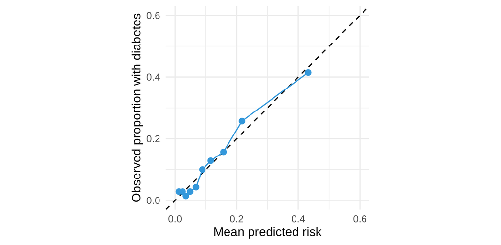

## Calibration slope and intercept

```r
lp <- qlogis(dev$risk)
round(coef(glm(diabetes ~ lp, data = dev, family = binomial)), 3)
```

```
(Intercept)          lp
          0           1
```

Intercept **0** and slope **1.000** in the development data: this is **guaranteed** when a logistic model is fitted by maximum likelihood. It says **nothing** about new patients. In **new data**: **slope below 1** = predictions **too extreme** (overfitting); **intercept (calibration-in-the-large)** shows **average over- or under-estimation**.

## Brier score

```r
brier <- mean((dev$risk - dev$diabetes)^2); brier_null <- mean((mean(dev$diabetes) - dev$diabetes)^2)
round(c(brier = brier, scaled = 1 - brier / brier_null), 3)
```

```
 brier scaled
 0.089  0.155
```

- **Brier** = mean squared difference between **risk and outcome** (0 = perfect); combines **discrimination and calibration**
- **Scaled Brier** = 1 − Brier / Brier of “everyone gets the prevalence”: **0.15** here (0 = no better than the prevalence)
- Avoid the **Hosmer-Lemeshow test**: it depends on the grouping, has low power and says **nothing about how** the calibration fails

## 🔧 Switch to R — Lab 2

**File:** `prediction-workshop/labs/lab2_perf.R`

- ROC, AUC and its CI
- threshold, sensitivity, specificity, PPV, NPV
- calibration plot, slope, Brier score

**Time:** 40 minutes · answer the Q questions in the comments

## Self-check quiz (1/5)

How do you read an AUC of 0.80?

- 80% of the adults are classified correctly if a threshold of 50% is used
- The predicted risks are within 20% of the true risks, on average, for adults
- A random case has a higher risk than a random non-case, 80% of the time
- The model explains 80% of the variation in diabetes within the cohort studied

## Self-check quiz (2/5)

A threshold of 15% gives a sensitivity of 0.62. What happens when the threshold is lowered to 5%?

- Both sensitivity and specificity rise
- Sensitivity rises and specificity falls
- Sensitivity falls and specificity rises
- Neither changes, since the AUC does not depend on the threshold

## Self-check quiz (3/5)

In the development data the calibration slope is exactly 1 and the intercept 0. What does this tell you?

- The model is well calibrated and will be well calibrated in other cohorts
- The model does not overfit, since the slope is not below 1 in these data
- Nothing about new patients: it is guaranteed by the fitting
- The predicted risks are accurate for each of the risk groups in the cohort

## Self-check quiz (4/5)

In a calibration plot the points lie below the diagonal at high predicted risk. What does that mean?

- The model under-estimates risk, since more events are observed than predicted
- The model discriminates poorly, with an AUC close to 0.5
- The sample is too small to draw a calibration plot
- The model over-estimates risk: fewer events are observed than predicted

## Self-check quiz (5/5)

Why do PPV and NPV differ between a screening clinic and the general population for the same model?

- They depend on the prevalence of the disease in the population
- The AUC of the model changes with the setting by definition
- Sensitivity and specificity are defined in clinics but not elsewhere
- The threshold has to be changed when the setting changes

## Score and take-home

**Your score:**

- **Discrimination**: AUC = chance of ranking a case above a non-case
- **Threshold**: sensitivity, specificity; PPV/NPV depend on **prevalence**
- **Calibration**: plot, **slope** (spread), **intercept** (average level)
- Apparent slope is always **1**: check in **new data**
- **Brier** combines both; avoid Hosmer-Lemeshow

**Next:** Session 3: overfitting and internal validation